# Machine Learning for Signal Processing

### (ENGR-E 511)

### Homework 2

## Problem 1: De-beeper

### Initializing the required libraries

```python
# Importing all Required Libraries
import os
import pandas as pd
import numpy as np
import librosa as lb
from scipy import io
from scipy.io import wavfile
import matplotlib.pyplot as plt
import seaborn as sns
from IPython.display import Audio
```

### Loading and Listening to Audio file

```python
# Loading the data
data_x,shr= wavfile.read('E:/JupiterNotebook/HW2-Data/x.wav')

# Checking the data and listening to it
print('Original audio file')
Audio(shr, rate = 16000)
```

```
Original audio file
```

[interactive chart not shown]

#### Plotting the audio Signal

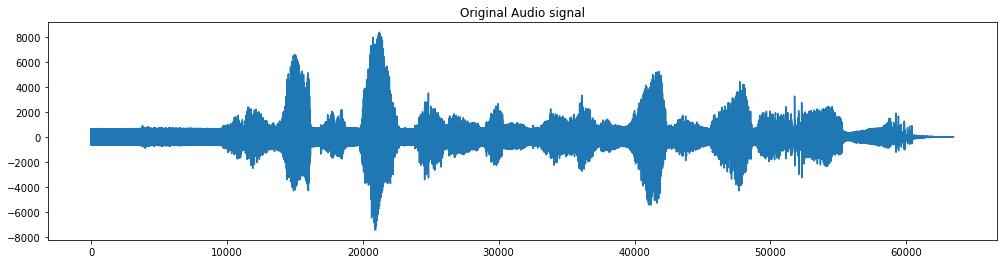

```python
# Ploting Audio signals
shr_range = range(shr.shape[0])
plt.figure(figsize= (17,4))
plt.title("Original Audio signal")
plt.plot(shr_range, shr)
plt.show()
```

#### We can listen thet the audio has a beep sound in it

### creating function for DFT matrix

```python
# DFD Matrix
def dft_matrix(N):
    dft_matrix = np.array([[np.exp(-1j * (2 * np.pi * f * n / N)) for f in range(0, N)] for n in range(0, N)])
    return dft_matrix
```

#### Taking N=2000, Hence creatng 2000x2000 DFT matrix

```python
#Initialising and cheking matrix shape
N=2000
dft_mt = dft_matrix(N)
print('Resulting DFT matrix shape is: ' + str(dft_mt.shape)) #Checking the matrix shape
#print(dft_mt)
```

```
Resulting DFT matrix shape is: (2000, 2000)
```

#### Appling Hann Window by applying Data Matrix

```python
# function for Hann Window
def hann_window(data, N):
    #Initializing values
    new_data = []
    count = 0
    hann_win = np.hanning(N)

    while count + N <= data.shape[0]:
        data_win = np.multiply(data[count:count+N], hann_win)
        new_data.append(data_win)

        count += int(N/2)

    new_data_mat = np.array(new_data).T

    return new_data_mat
```

```python
# Calculating hann window and cheking the shapes
shr_data = hann_window(shr, N)
print('Original frequency spectrum shape is:' + str(shr.reshape(-1,1).shape))
print('Shape of new data matrix after applying hanning window:' + str(shr_data.shape))
```

```
Original frequency spectrum shape is:(63488, 1)
Shape of new data matrix after applying hanning window:(2000, 62)
```

#### Plotting the Spectrogram of Original Audio

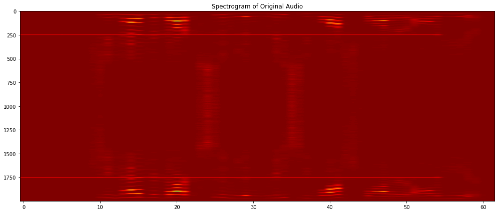

```python
#Plotting the Spectrogram of Original Audio
spectro = np.dot(dft_mt, shr_data)
spectro_abs = np.abs(spectro)

plt.figure(figsize= (17,7))
plt.title("Spectrogram of Original Audio")
plt.imshow(spectro_abs, cmap='jet_r', aspect='auto')
plt.show()
```

#### From the above Spectrogram, We clearly can see the two horizontal lines due to the beep sound in the audio.

#### Now Trying to remove the beep noise

```python
#removing the beep noise
noise_window = np.mean(spectro_abs[:,spectro_abs.shape[1] - 200:], axis = 1).reshape(-1,1)
cleaned_spectro = spectro_abs - noise_window
cleaned_spectro[cleaned_spectro<0] = 0

original_mag = np.multiply(spectro, 1 / spectro_abs)
clean_spectro = np.multiply(original_mag, cleaned_spectro)
```

#### Function for Inverse DFD Matrix

```python
#Inverse DFD Matrix
def inverse_dft_matrix(N):

    dft_mt = np.array([[np.exp(1j * (2 * np.pi * f * n /N)) for f in range(0,N)] for n in range(0,N)])
    inverse_dft_mt = dft_mt/N

    return inverse_dft_mt
```

```python
#Calculating Inverse DFD
in_dft_mt = inverse_dft_matrix(N)

print('Resulting inverse DFT matrix shape is:' + str(in_dft_mt.shape))
```

```
Resulting inverse DFT matrix shape is:(2000, 2000)
```

```python
#Check if F*F is an identity matrix
f_str_f = np.dot(in_dft_mt, dft_mt)
print(str(np.abs(np.round(f_str_f.real))))
print('We can observe from above that, F*F is an identity matrix')
```

```
[[1. 0. 0. ... 0. 0. 0.]
 [0. 1. 0. ... 0. 0. 0.]
 [0. 0. 1. ... 0. 0. 0.]
 ...
 [0. 0. 0. ... 1. 0. 0.]
 [0. 0. 0. ... 0. 1. 0.]
 [0. 0. 0. ... 0. 0. 1.]]
We can observe from above that, F*F is an identity matrix
```

#### Taking a dot product of the inverse dft matrix with the recovered of the data matrix for Recovering the clean audio signal

```python
#Taking Dot Product
shr_new = np.dot(in_dft_mt, clean_spectro)
```

#### Function for taking real values and reversing the overlap

```python
#Function to reversing the overlap
def rev_overlap(data, N):

    new_data = data[:(data.shape[0] - int(N/2)),0]
    for col in range(1,data.shape[1]):
        new_data_col = data[(data.shape[0] - int(N/2)):,col-1] + data[0:int(N/2),col]
        new_data = np.concatenate((new_data,new_data_col))

    new_data = new_data.reshape(-1)

    return new_data
```

```python
#Writing the New Obtained audio file
reco_audio_signal = rev_overlap(shr_new.real, 2000)
wavfile.write(('E:/JupiterNotebook/HW2-Data/cleaned_output.wav'),data_x, reco_audio_signal)
```

```python
# Loading the New Recoverd Audio File
data_x,new_shr= wavfile.read('E:/JupiterNotebook/HW2-Data/cleaned_output.wav')

# Checking Recoverd Audio File and listening to it

print('Recoveres audio file audio file')
Audio(new_shr, rate = 16000)
```

```
Recoveres audio file audio file
```

[interactive chart not shown]

#### Hearing to the recoved audio we can observe that most of the beep sound is removed

#### Now ploting the Recoverd audio signal and comapring to the original signal

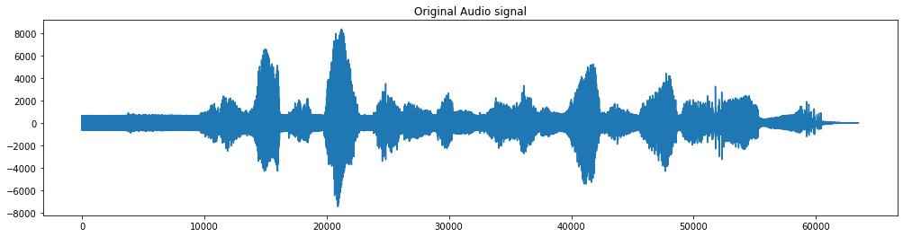

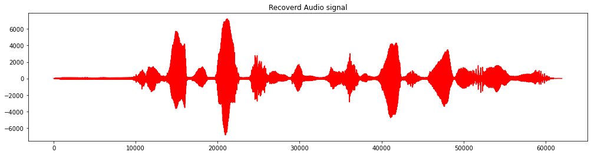

```python
# Ploting Audio signals
shr_range = range(shr.shape[0])
plt.figure(figsize= (17,4))
plt.title("Original Audio signal")
plt.plot(shr_range, shr)
plt.show

#Ploting recovered signal
new_shr_range = range(new_shr.shape[0])
plt.figure(figsize= (17,4))
plt.title("Recoverd Audio signal")
plt.plot(new_shr_range, new_shr ,color = 'red')
plt.show()
```

#### In original audio file plot we can see it has spikes because of the beep present in the audio. In the recovered Audio we can see that the plot is less spiky.

```
Original frequency spectrum shape is:(62000, 1)
Shape of new data matrix after applying hanning window:(2000, 61)
```

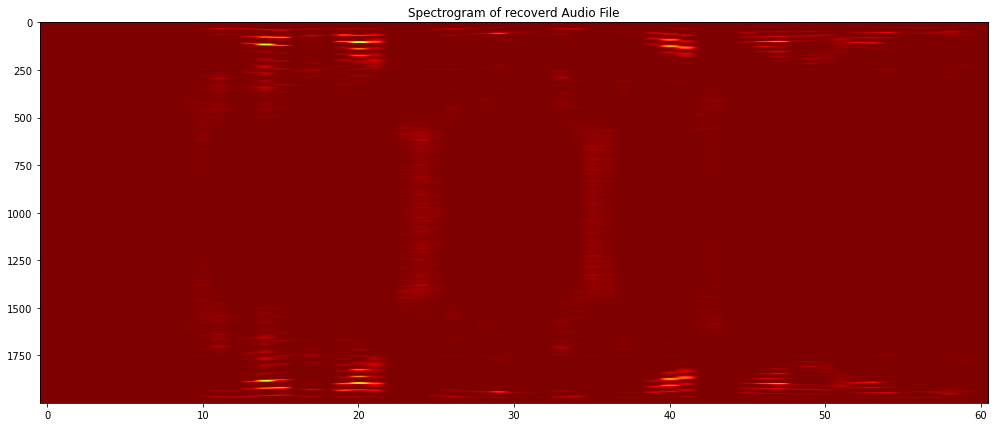

```python
#Cheking data
new_shr_data = hann_window(new_shr, N)
print('Original frequency spectrum shape is:' + str(new_shr.reshape(-1,1).shape))
print('Shape of new data matrix after applying hanning window:' + str(new_shr_data.shape))

spectro = np.dot(in_dft_mt, new_shr_data)
spectro_abs = np.abs(spectro)

#Plotting the data
plt.figure(figsize= (17,7))
plt.title("Spectrogram of recoverd Audio File")
plt.imshow(spectro_abs, cmap='jet_r', aspect='auto')
plt.show()
```

#### Comparing to the Spectrogram of the Original Audio we can see that the spectrogram of Recovered audio has no horizontal lines.

## Problem 2: Parallax

#### Loading the data

```python
#Loading data From fs
june = io.loadmat("E:/JupiterNotebook/HW2-Data/june.mat")['june']
december = io.loadmat("E:/JupiterNotebook/HW2-Data/december.mat")['december']
print(june.shape)
print(december.shape)
```

```
(2700, 2)
(2700, 2)
```

#### Calculating Disparity Matrix

```python
#Calculation of  Disparity Matrix
disparity_mat = december[:,0] - june[:,0]
disparity_mat = disparity_mat.reshape(-1,1)

print('The Disparity matrix shape is: ' + str(disparity_mat.shape))
```

```
The Disparity matrix shape is: (2700, 1)
```

#### Plotting the Calculated Disparity Matrix

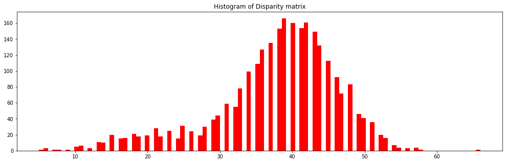

```python
#Plotting Disparity Matrix
plt.figure(figsize = (17,5))
plt.title('Histogram of Disparity matrix')
plt.hist(disparity_mat, bins = 100, color = 'red')
plt.show()
```

#### From the Histogram, we can observe that there are two clusters with diffrent means in the shape of two overlapping normal distribution.

#### Function to calculate K-Means Clustoring

```python
#Function to find the clusters
def k_Means_Clustering(data, no_of_clust, max_iter, tol):

    #initiating two random cluster centroids
    clust = np.random.uniform(low = int(min(data)), high = int(max(data)), size = no_of_clust).reshape(-1,1)
    clust_mat = np.array([[0.0] * no_of_clust] * data.shape[0])

    iter = 0
    while iter <= max_iter:

        for i in range(0, len(data)):
             # Calculating the distane of each points from both the centroids
             # Distance for which centorid is minimum, value will be updated to 1
            if (np.abs(data[i] - clust[0])) < (np.abs(data[i] - clust[1])):
                clust_mat[i][0] = 1
                clust_mat[i][1] = 0
            else:
                clust_mat[i][1] = 1
                clust_mat[i][0] = 0

        #Assigning
        clust_prev = clust

        clust_centroids_dot_mat = np.dot(data.T, clust_mat)
        tot_sum = np.sum(clust_mat, axis = 0)

        clust = (clust_centroids_dot_mat/tot_sum).reshape(-1)
        #Printing calculated clusters
        print(clust)

        #Incrementing itrator
        iter += 1

         #Early stopping if if new mean minus old mean match are lower than tolerance then the k-means algorithm stops
        if np.abs(clust[0] - clust_prev[0]) < tol and np.abs(clust[1] - clust_prev[1]) < tol:
            break

    # Preparing Data For Plotting
    res_df = pd.DataFrame(data)
    res_df.columns = ['Calculated Disparity Data']
    res_df['Cluster'] = np.argmax(clust_mat, axis = 1)


    return clust, res_df
```

```python
#Calculating the clusters
clusters, dataframe = k_Means_Clustering(disparity_mat, no_of_clust = 2, max_iter = 500, tol = 0.002)
```

```
[40.73857645 22.44339623]
[40.9977447  23.48861284]
[41.226642   24.35873606]
[41.226642   24.35873606]
```

```python
#ignorig warnings while plotting data
import warnings
warnings.simplefilter(action="ignore", category=FutureWarning)
```

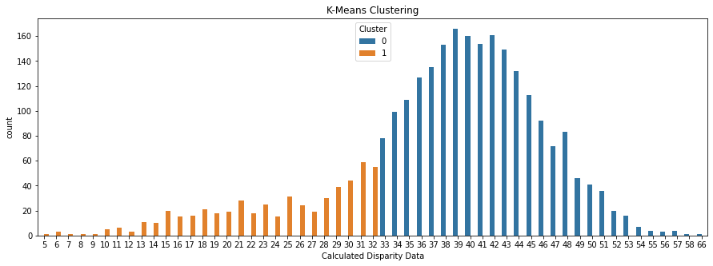

```python
#Plotting the Data an seeing clusters
plt.figure(figsize = (15,5))
sns.countplot(dataframe['Calculated Disparity Data'], hue = dataframe['Cluster']).set_title("K-Means Clustering")
plt.show()
```

```python
# Cluster centroids upto 3 significant figures
print('The calculated cluster centroids are ' + str(round(clusters[0], 3)) + ' and ' + str(round(clusters[1], 3)))
```

```
The calculated cluster centroids are 41.227 and 24.359
```

### Conclusion

#### As relative to the earth the stars in our galaxy changes their position more often, hence it has the higher cluster mean compared to our neighboring galaxy as they will change their position very slowly relative to the earth.

## Problem 3: GMM for Parallax

#### Function to calculate Probabilities

```python
# Function to calculate Probabilities
def pdf_dist_normal(µ, σ, x):
    pdf = (1/np.sqrt((2*np.pi*(σ**2)))) * (np.exp(-(((x-µ)**2)/(2*(σ**2)))))
    return pdf
```

#### Function For calculating GMM by EM (expectation maximization)

```python
def EM(data, max_iter, tol):
    #Initialising probability of the number of stars in clusters
    P_A = 0.1
    P_B = 0.9

    #initialising the centroids calculated using k-Means clustering
    M_A, M_B = 27.743, 42.312
    #initialising the sds
    sd_A, sd_B = 5, 5

    iter = 0

    while iter <= max_iter:
        #Calculating Probabilities
        P_X_given_A = pdf_dist_normal(M_A, sd_A, data)
        P_X_given_B = pdf_dist_normal(M_B, sd_B, data)
        P_X_given_A[P_X_given_A == 0] = 0.05
        P_X_given_B[P_X_given_B == 0] = 0.05

        #E (expectation)-step
        likeli_A = (P_A * P_X_given_A)/((P_A * P_X_given_A) + (P_B * P_X_given_B))
        likeli_B = (P_B * P_X_given_B)/((P_A * P_X_given_A) + (P_B * P_X_given_B))

        prev_M_A = M_A
        prev_M_B = M_B

        #M (maximization)-step

        # Calculating new Means
        M_A = np.sum(likeli_A * data)/np.sum(likeli_A)
        M_B = np.sum(likeli_B * data)/np.sum(likeli_B)

        # Calculating new SDs
        sd_A = np.sqrt(np.sum(likeli_A * (data - M_A) * (data - M_A))/np.sum(likeli_A))
        sd_B = np.sqrt(np.sum(likeli_B * (data - M_B) * (data - M_B))/np.sum(likeli_B))

        #Incrementing itrator
        iter += 1

        #Printing the Data
        print(M_A, M_B)

        #Early stopping
        if np.abs(M_A - prev_M_A) < tol and np.abs(M_B - prev_M_B) < tol:
            break

    # Getting cluster matrix and data
    # Preparing Data For Plotting
    cluster_mat = np.argmax(np.concatenate((likeli_A, likeli_B), axis = 1), axis = 1)
    EM_df = pd.DataFrame(data)
    EM_df.columns = ['Calculated Disparity Data']
    EM_df['Cluster'] = cluster_mat

    return M_A, M_B, EM_df
```

```python
mean_A, mean_B, EM_df = EM(disparity_mat,1000, 0.0001)
```

```
24.613006138502186 40.98450566537851
23.070523983878008 40.517342555293524
22.089503249229004 40.30671820187714
21.44835648498788 40.20192960556173
21.0132072399084 40.14241315479803
20.711120882885773 40.10377458997044
20.499010343616995 40.07640467465002
20.34925760127558 40.05631958455233
20.243254293895248 40.04149950406521
20.16812697512237 40.030626848127824
20.114851632401102 40.02271328723437
20.07706218895881 40.0169936395215
20.05025398646268 40.012881846203506
20.031234950985066 40.00993744369756
20.017741615687633 40.00783482206861
20.00816848442308 40.00633623622504
20.001376606148735 40.005269610930604
19.996557951060023 40.00451115757941
19.993139247378107 40.0039721982304
19.9907137731829 40.00358939164498
19.988992968942664 40.00331758548886
19.98777210869113 40.00312463853288
19.986905944570772 40.002987693891946
19.98629142709858 40.00289050837285
19.985855445518638 40.00282154440155
19.985546129832997 40.00277260962612
19.985326679788592 40.002737888407346
19.985170986694712 40.00271325300944
19.9850605272167 40.002695774066424
19.984982159607622 40.00268337284834
```

```python
# Printing GMM cluster mean upto 3 significanr figures
print('Cluster means caculated using GMM algorithm are: ' + str(np.round(mean_A, 3))+ ' and ' + str(np.round(mean_B, 3)))
```

```
Cluster means caculated using GMM algorithm are: 19.985 and 40.003
```

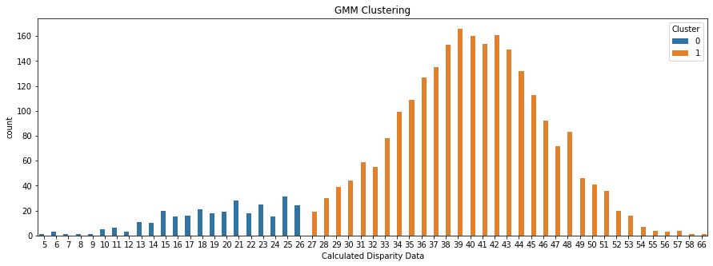

```python
#Plotting the Data an seeing clusters
plt.figure(figsize = (15,5))
sns.countplot(EM_df['Calculated Disparity Data'], hue = EM_df['Cluster']).set_title("GMM Clustering")
plt.show()
```

### Conclusion:

#### As we know that k-means algorithm uses distance metrics, so the distance boundries are hard while GMM uses the probability of data points belonging to a cluster, hence its boundiers are soft.

#### Also the k-means algoritjm uses dtapoints in a circle (as it is a circle bound) while GMM uses elliptical shapes

#### As a result of ths whole, The GMM algorithm does a better then k-means to cluster the neighbouring galay star to our galay stars.

## Refrences :

Implementation and Equations for GMM referenced from:

https://python-course.eu/machine-learning/expectation-maximization-and-gaussian-mixture-models-gmm.php

http://www.oranlooney.com/post/ml-from-scratch-part-5-gmm/